# Program

# Chapter 17: Introduction

In this part of the book, you’ll improve your programming skills. Programming is a cross-cutting skill needed for all data science work: you must use a computer to do data science; you cannot do it in your head, or with pencil and paper.

Programming produces code, and code is a tool of communication. Obviously code tells the computer what you want it to do. But it also communicates meaning to other humans. Thinking about code as a vehicle for communication is important because every project you do is fundamentally collaborative. Even if you’re not working with other people, you’ll definitely be working with future-you! Writing clear code is important so that others (like future-you) can understand why you tackled an analysis in the way you did. That means getting better at programming also involves getting better at communicating. Over time, you want your code to become not just easier to write, but easier for others to read.

Writing code is similar in many ways to writing prose. One parallel which I find particularly useful is that in both cases rewriting is the key to clarity. The first expression of your ideas is unlikely to be particularly clear, and you may need to rewrite multiple times. After solving a data analysis challenge, it’s often worth looking at your code and thinking about whether or not it’s obvious what you’ve done. If you spend a little time rewriting your code while the ideas are fresh, you can save a lot of time later trying to recreate what your code did. But this doesn’t mean you should rewrite every function: you need to balance what you need to achieve now with saving time in the long run. (But the more you rewrite your functions the more likely your first attempt will be clear.)

In the following four chapters, you’ll learn skills that will allow you to both tackle new programs and to solve existing problems with greater clarity and ease:

In pipes, you will dive deep into the pipe, %>%, and learn more about how it works, what the alternatives are, and when not to use it.

Copy-and-paste is a powerful tool, but you should avoid doing it more than twice. Repeating yourself in code is dangerous because it can easily lead to errors and inconsistencies. Instead, in functions, you’ll learn how to write functions which let you extract out repeated code so that it can be easily reused.

As you start to write more powerful functions, you’ll need a solid grounding in R’s data structures, provided by vectors. You must master the four common atomic vectors, the three important S3 classes built on top of them, and understand the mysteries of the list and data frame.

Functions extract out repeated code, but you often need to repeat the same actions on different inputs. You need tools for iteration that let you do similar things again and again. These tools include for loops and functional programming, which you’ll learn about in iteration.

## 17.1 For further study

The goal of these chapters is to teach you the minimum about programming that you need to practice data science, which turns out to be a reasonable amount. Once you have mastered the material in this book, I strongly believe you should invest further in your programming skills. Learning more about programming is a long-term investment: it won’t pay off immediately, but in the long term it will allow you to solve new problems more quickly, and let you reuse your insights from previous problems in new scenarios.

To learn more you need to study R as a programming language, not just an interactive environment for data science. We have written two books that will help you do so:

Hands on Programming with R, by Garrett Grolemund. This is an introduction to R as a programming language and is a great place to start if R is your first programming language. It covers similar material to these chapters, but with a different style and different motivation examples (based in the casino). It’s a useful complement if you find that these four chapters go by too quickly.

Advanced R by Hadley Wickham. This dives into the details of R the programming language. This is a great place to start if you have existing programming experience. It’s also a great next step once you’ve internalised the ideas in these chapters. You can read it online at http://adv-r.had.co.nz.

# Chapter 18 Pipes

## 18.1 Introduction

Pipes are a powerful tool for clearly expressing a sequence of multiple operations. So far, you’ve been using them without knowing how they work, or what the alternatives are. Now, in this chapter, it’s time to explore the pipe in more detail. You’ll learn the alternatives to the pipe, when you shouldn’t use the pipe, and some useful related tools.

### 17.1.1 Prerequisites

```r
library(tidyverse)
library(purrr)
library(magrittr)
# install.packages("pryr")
library(pryr)
```

## 18.2 Piping alternatives

The point of the pipe is to help you write code in a way that is easier to read and understand. To see why the pipe is so useful, we’re going to explore a number of ways of writing the same code. Let’s use code to tell a story about a little bunny named Foo Foo: >Little bunny Foo Foo Went hopping through the forest Scooping up the field mice And bopping them on the head

This is a popular Children’s poem that is accompanied by hand actions.We’ll start by defining an object to represent little bunny Foo Foo:

```r
# foo_foo <- little_bunny()
```

And we’ll use a function for each key verb: `hop()`, `scoop()`, and `bop()`. Using this object and these verbs, there are (at least) four ways we could retell the story in code:

1. Save each intermediate step as a new object.
2. Overwrite the original object many times.
3. Compose functions.
4. Use the pipe.

We’ll work through each approach, showing you the code and talking about the advantages and disadvantages.

### 18.2.1 Intermediate steps

The simplest approach is to save each step as a new object:

```r
# foo_foo_1 <- hop(foo_foo,through=forest)
# foo_foo_2 <- scoop(foo_foo_1, up = field_mice)
# foo_foo_3 <- bop(foo_foo_2, on = head)
```

The main downside of this form is that it forces you to name each intermediate element. If there are natural names, this is a good idea, and you should do it. But many times, like this in this example, there aren’t natural names, and you add numeric suffixes to make the names unique. That leads to two problems:

1. The code is cluttered with unimportant names
2. You have to carefully increment the suffix on each line.

Whenever I write code like this, I invariably use the wrong number on one line and then spend 10 minutes scratching my head and trying to figure out what went wrong with my code.

You may also worry that this form creates many copies of your data and takes up a lot of memory. Surprisingly, that’s not the case. First, note that proactively worrying about memory is not a useful way to spend your time: worry about it when it becomes a problem (i.e. you run out of memory), not before. Second, R isn’t stupid, and it will share columns across data frames, where possible. Let’s take a look at an actual data manipulation pipeline where we add a new column to `ggplot2::diamonds`:

```r
diamonds <- ggplot2::diamonds
diamonds2 <- diamonds %>%
  dplyr::mutate(price_per_carat=price/carat)

pryr::object_size(diamonds)
```

```
## 3.46 MB
```

```r
pryr::object_size(diamonds2)
```

```
## 3.89 MB
```

```r
pryr::object_size(diamonds,diamonds2)
```

```
## 3.89 MB
```

`pryr::object_size()` gives the memory occupied by all of its arguments. The results seem counterintuitive at first:

- `diamonds` takes up 3.46 MB,
- `diamonds2` takes up 3.89 MB,
- `diamonds` and `diamonds2` together take up 3.89 MB!

How can that work? Well, `diamonds2` has 10 columns in common with `diamonds`: there’s no need to duplicate all that data, so the two data frames have variables in common. These variables will only get copied if you modify one of them. In the following example, we modify a single value in `diamonds$carat`. That means the `carat` variable can no longer be shared between the two data frames, and a copy must be made. The size of each data frame is unchanged, but the collective size increases:

```r
diamonds$carat[1] <- NA
pryr::object_size(diamonds)
```

```
## 3.46 MB
```

```r
pryr::object_size(diamonds2)
```

```
## 3.89 MB
```

```r
pryr::object_size(diamonds,diamonds2)
```

```
## 4.32 MB
```

(Note that we use `pryr::object_size()` here, not the built-in `object.size()`. `object.size()` only takes a single object so it can’t compute how data is shared across multiple objects.)

### 18.2.2 Overwrite the original

Instead of creating intermediate objects at each step, we could overwrite the original object:

```r
# foo_foo <- hop(foo_foo, through = forest)
# foo_foo <- scoop(foo_foo, up = field_mice)
# foo_foo <- bop(foo_foo, on = head)
```

This is less typing (and less thinking), so you’re less likely to make mistakes. However, there are two problems:

1. Debugging is painful: if you make a mistake you’ll need to re-run the complete pipeline from the beginning.
2. The repetition of the object being transformed (we’ve written foo_foo six times!) obscures what’s changing on each line.

### 18.2.3 Function composition

Another approach is to abandon assignment and just string the function calls together:

```r
# bop(
#   scoop(
#     hop(foo_foo, through = forest),
#     up = field_mice
#   ),
#   on = head
# )
```

Here the disadvantage is that you have to read from inside-out, from right-to-left, and that the arguments end up spread far apart (evocatively called the dagwood sandwhich problem). In short, this code is hard for a human to consume.

### 18.2.4 Use the pipe

Finally, we can use the pipe:

```r
# foo_foo %>%
#   hop(through = forest) %>%
#   scoop(up = field_mice) %>%
#   bop(on = head)
```

This is my favourite form, because it focusses on verbs, not nouns. You can read this series of function compositions like it’s a set of imperative actions. Foo Foo hops, then scoops, then bops. The downside, of course, is that you need to be familiar with the pipe. If you’ve never seen `%>%` before, you’ll have no idea what this code does. Fortunately, most people pick up the idea very quickly, so when you share your code with others who aren’t familiar with the pipe, you can easily teach them.

The pipe works by performing a “lexical transformation”: behind the scenes, magrittr reassembles the code in the pipe to a form that works by overwriting an intermediate object. When you run a pipe like the one above, magrittr does something like this:

```r
# my_pipe <- function(.) {
#   . <- hop(., through = forest)
#   . <- scoop(., up = field_mice)
#   bop(., on = head)
# }
# my_pipe(foo_foo)
```

This means that the pipe won’t work for two classes of functions:

1. Functions that use the current environment. For example, `assign()` will create a new variable with the given name in the current environment:

```r
assign("x",10)
x
```

```
## [1] 10
```

```r
"x" %>% assign(100)
x
```

```
## [1] 10
```

The use of assign with the pipe does not work because it assigns it to a temporary environment used by `%>%`. If you do want to use assign with the pipe, you must be explicit about the environment:

```r
env <- environment()
"x" %>% assign(100,envir=env)
x
```

```
## [1] 100
```

Other functions with this problem include `get()` and `load()`.

2. Functions that use lazy evaluation. In R, function arguments are only computed when the function uses them, not prior to calling the function. The pipe computes each element in turn, so you can’t rely on this behaviour.

One place that this is a problem is `tryCatch()`, which lets you capture and handle errors:

```r
# tryCatch(stop("!"),error=function(e)"An error")
#
# stop("!") %>%
#   tryCatch(error = function(e) "An error")
# # Error in eval(lhs, parent, parent) : !
```

There are a relatively wide class of functions with this behaviour, including `try()`, `suppressMessages()`, and `suppressWarnings()` in base R.

## 18.3 When not to use the pipe

The pipe is a powerful tool, but it’s not the only tool at your disposal, and it doesn’t solve every problem! Pipes are most useful for rewriting a fairly short linear sequence of operations. I think you should reach for another tool when:

- Your pipes are longer than (say) ten steps. In that case, create intermediate objects with meaningful names. That will make debugging easier, because you can more easily check the intermediate results, and it makes it easier to understand your code, because the variable names can help communicate intent.
- You have multiple inputs or outputs. If there isn’t one primary object being transformed, but two or more objects being combined together, don’t use the pipe.
- You are starting to think about a directed graph with a complex dependency structure. Pipes are fundamentally linear and expressing complex relationships with them will typically yield confusing code.

## 18.4 Other tools from magrittr

All packages in the tidyverse automatically make `%>%` available for you, so you don’t normally load magrittr explicitly. However, there are some other useful tools inside magrittr that you might want to try out:

- When working with more complex pipes, it’s sometimes useful to call a function for its side-effects. Maybe you want to print out the current object, or plot it, or save it to disk. Many times, such functions don’t return anything, effectively terminating the pipe.

To work around this problem, you can use the “tee” pipe. `%T>%` works like `%>%` except that it returns the left-hand side instead of the right-hand side. It’s called “tee” because it’s like a literal T-shaped pipe.

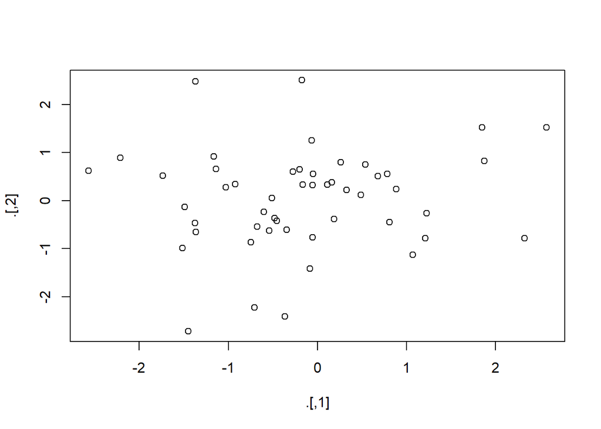

```r
rnorm(100) %>%
  matrix(ncol=2) %>%
  plot() %>%
  str()
```

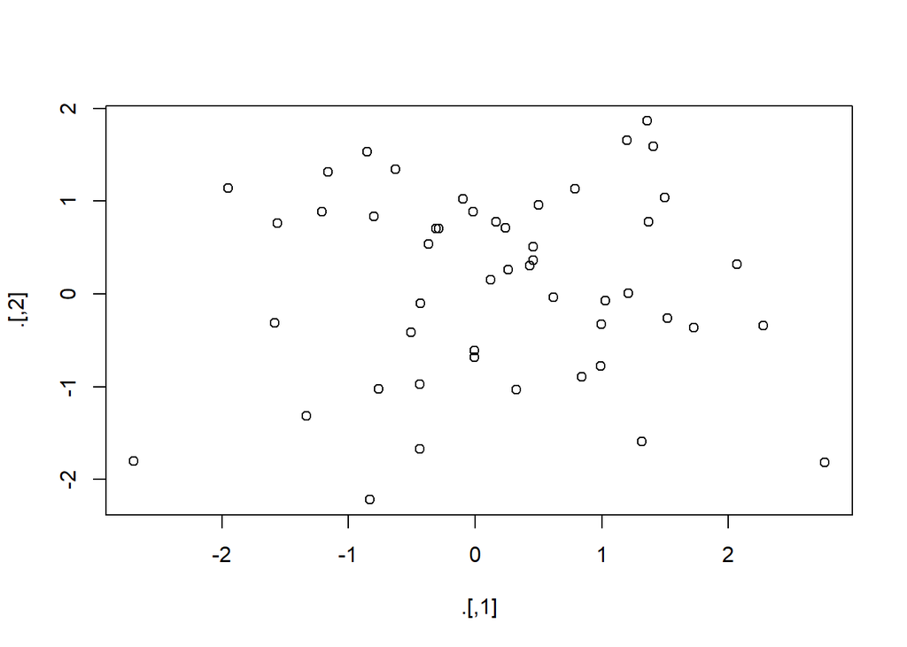

```r
rnorm(100) %>%
  matrix(ncol=2) %>%
  plot() %>%
  str()
```

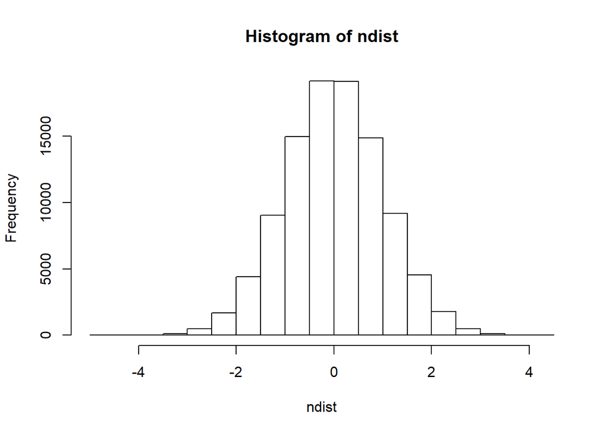

```r
ndist <- rnorm(100000)
hist(ndist)
```

- If you’re working with functions that don’t have a data frame based API (i.e. you pass them individual vectors, not a data frame and expressions to be evaluated in the context of that data frame), you might find `%$%` useful. It “explodes” out the variables in a data frame so that you can refer to them explicitly. This is useful when working with many functions in base R:

```r
mtcars %$%
  cor(disp, mpg)
```

```
## [1] -0.8475514
```

- For assignment magrittr provides the `%<>%` operator which allows you to replace code like:

```r
mtcars <- mtcars %>%
  transform(cyl=cyl*2)
```

with

```r
mtcars %<>% transform(cyl=cyl*2)
```

I’m not a fan of this operator because I think assignment is such a special operation that it should always be clear when it’s occurring. In my opinion, a little bit of duplication (i.e. repeating the name of the object twice) is fine in return for making assignment more explicit.

# Chapter 19 Functions

## 19.1 Introduction

One of the best ways to improve your reach as a data scientist is to write functions. Functions allow you to automate common tasks in a more powerful and general way than copy-and-pasting. Writing a function has three big advantages over using copy-and-paste:

1. You can give a function an evocative name that makes your code easier to understand.
2. As requirements change, you only need to update code in one place, instead of many.
3. You eliminate the chance of making incidental mistakes when you copy and paste (i.e. updating a variable name in one place, but not in another).

Writing good functions is a lifetime journey. Even after using R for many years I still learn new techniques and better ways of approaching old problems. The goal of this chapter is not to teach you every esoteric detail of functions but to get you started with some pragmatic advice that you can apply immediately.

As well as practical advice for writing functions, this chapter also gives you some suggestions for how to style your code. Good code style is like correct punctuation. Youcanmanagewithoutit, but it sure makes things easier to read! As with styles of punctuation, there are many possible variations. Here we present the style we use in our code, but the most important thing is to be consistent.

## 19.1.1 Prerequisites

The focus of this chapter is on writing functions in base R, so you won’t need any extra packages.

## 19.2 When should you write a function?

You should consider writing a function whenever you’ve copied and pasted a block of code more than twice (i.e. you now have three copies of the same code). For example, take a look at this code. What does it do?

```r
df <- tibble::tibble(
  a = rnorm(10),
  b = rnorm(10),
  c = rnorm(10),
  d = rnorm(10)
)
df
```

```
## # A tibble: 10 x 4
##          a      b        c       d
##      <dbl>  <dbl>    <dbl>   <dbl>
##  1 -0.0720  1.53  -0.0213   1.54
##  2  1.45   -0.129  0.415    0.243
##  3 -0.860   0.313 -1.12     1.24
##  4  0.255   0.237  0.00922  0.757
##  5 -0.0561 -0.114  0.0416  -0.0165
##  6 -1.13   -0.106 -0.452    0.890
##  7  0.132   0.471 -0.746    0.434
##  8  0.221   0.385  0.583   -0.623
##  9 -1.12   -1.13   0.238   -0.652
## 10  0.975   1.47   1.56     0.242
```

```r
df$a <- (df$a - min(df$a, na.rm = TRUE)) /
  (max(df$a, na.rm = TRUE) - min(df$a, na.rm = TRUE))
df$b <- (df$b - min(df$b, na.rm = TRUE)) /
  (max(df$b, na.rm = TRUE) - min(df$a, na.rm = TRUE))
df$c <- (df$c - min(df$c, na.rm = TRUE)) /
  (max(df$c, na.rm = TRUE) - min(df$c, na.rm = TRUE))
df$d <- (df$d - min(df$d, na.rm = TRUE)) /
  (max(df$d, na.rm = TRUE) - min(df$d, na.rm = TRUE))
```

You might be able to puzzle out that this rescales each column to have a range from 0 to 1. But did you spot the mistake? I made an error when copying-and-pasting the code for `df$b`: I forgot to change an `a` to a `b`. Extracting repeated code out into a function is a good idea because it prevents you from making this type of mistake.

To write a function, you need to first analyze the code. How many inputs does it have?

```r
(df$a - min(df$a, na.rm = TRUE)) /
  (max(df$a, na.rm = TRUE) - min(df$a, na.rm = TRUE))
```

```
##  [1] 0.410320788 1.000000000 0.105410707 0.536743430 0.416492071
##  [6] 0.000000000 0.489446078 0.523895926 0.006204237 0.815650649
```

This code only has one input: `df$a`. (If you’re surprised that `TRUE` is not an input, you can explore why in the exercise below.) To make the inputs more clear, it’s a good idea to rewrite the code using temporary variables with general names. Here this code only requires a single numeric vector, so I’ll call it `x`:

```r
x <- df$a
(x - min(x, na.rm = T)) / (max(x, na.rm = T)-min(x, na.rm = T))
```

```
##  [1] 0.410320788 1.000000000 0.105410707 0.536743430 0.416492071
##  [6] 0.000000000 0.489446078 0.523895926 0.006204237 0.815650649
```

There is some duplication in this code. We’re computing the range of the data three times, so it makes sense to do it in one step:

```r
rng <- range(x, na.rm = T)
(x-rng[1])/(rng[2]-rng[1])
```

```
##  [1] 0.410320788 1.000000000 0.105410707 0.536743430 0.416492071
##  [6] 0.000000000 0.489446078 0.523895926 0.006204237 0.815650649
```

Pulling out intermediate calculations into named variables is a good practice because it makes it more clear what the code is doing. Now that I’ve simplified the code, and checked that it still works, I can turn it into a function:

```r
rescale01 <- function(x){
  rng <- range(x, na.rm = T)
  (x-rng[1])/(rng[2]-rng[1])
}
rescale01(c(0,5,10))
```

```
## [1] 0.0 0.5 1.0
```

There are three key steps to creating a new function: 1. You need to pick a name for the function. Here I’ve used `rescale01` because this function rescales a vector to lie between 0 and 1. 2. You list the inputs, or arguments, to the `function` inside function. Here we have just one argument. If we had more the call would look like `function(x, y, z)`. 3. You place the code you have developed in body of the function, a { block that immediately follows `function(...)`.

Note that overall process: I only made the function after I’d figured out how to make it work with a simple input. It’s easier to start with working code and turn it into a function; it’s harder to create a function and then try to make it work.

At this point it’s a good idea to check your function with a few different inputs:

```r
rescale01(c(-10,0,10))
```

```
## [1] 0.0 0.5 1.0
```

```r
rescale01(c(1,2,3,NA,5))
```

```
## [1] 0.00 0.25 0.50   NA 1.00
```

As you write more and more functions you’ll eventually want to convert these informal, interactive tests into formal, automated tests. That process is called unit testing. Unfortunately, it’s beyond the scope of this book, but you can learn about it in http://r-pkgs.had.co.nz/tests.html.

We can simplify the original example now that we have a function:

```r
df$a <- rescale01(df$a)
df$b <- rescale01(df$b)
df$c <- rescale01(df$c)
df$d <- rescale01(df$d)
```

Compared to the original, this code is easier to understand and we’ve eliminated one class of copy-and-paste errors. There is still quite a bit of duplication since we’re doing the same thing to multiple columns. We’ll learn how to eliminate that duplication in iteration, once you’ve learned more about R’s data structures in vectors.

Another advantage of functions is that if our requirements change, we only need to make the change in one place. For example, we might discover that some of our variables include infinite values, and `rescale01()` fails:

```r
x <- c(1:10,Inf)
rescale01(x)
```

```
##  [1]   0   0   0   0   0   0   0   0   0   0 NaN
```

Because we’ve extracted the code into a function, we only need to make the fix in one place:

```r
rescale01 <- function(x){
  rng <- range(x,na.rm=T,finite=T)
  (x-rng[1])/(rng[2]-rng[1])
}
rescale01(x)
```

```
##  [1] 0.0000000 0.1111111 0.2222222 0.3333333 0.4444444 0.5555556 0.6666667
##  [8] 0.7777778 0.8888889 1.0000000       Inf
```

This is an important part of the “do not repeat yourself” (or DRY) principle. The more repetition you have in your code, the more places you need to remember to update when things change (and they always do!), and the more likely you are to create bugs over time.

### 19.2.1 Practice

1. Why is `TRUE` not a parameter to `rescale01()`? What would happen if x contained a single missing value, and `na.rm` was `FALSE`?

```r
rescale01 <- function(x){
  rng <- range(x,na.rm=F)
  (x-rng[1])/(rng[2]-rng[1])
}
rescale01(c(-1,0,5,20,NA))
```

```
## [1] NA NA NA NA NA
```

Everything is NA! We should set an argument to control the `TRUE` or `FALSE` of `range`.

2. In the second variant of `rescale01()`, infinite values are left unchanged. Rewrite `rescale01()` so that `-Inf` is mapped to 0, and `Inf` is mapped to 1.

```r
rescale01 <- function(x){
  rng <- range(x,na.rm=T,finite=T)
  (x-rng[1])/(rng[2]-rng[1])
  x[x==Inf]<-1
  x[x==-Inf] <- 0
  x
}

rescale01(c(Inf,-Inf,0:5,NA))
```

```
## [1]  1  0  0  1  2  3  4  5 NA
```

3. Practice turning the following code snippets into functions. Think about what each function does. What would you call it? How many arguments does it need? Can you rewrite it to be more expressive or less duplicative?

```r
mean(is.na(x))
```

```
## [1] 0
```

```r
x / sum(x, na.rm = TRUE)
```

```
##  [1]   0   0   0   0   0   0   0   0   0   0 NaN
```

```r
sd(x, na.rm = TRUE) / mean(x, na.rm = TRUE)
```

```
## [1] NaN
```

```r
prop_miss <- function(x){
  mean(is.na(x))
}

my_mean <- function(x){
  x/sum(x,na.rm=T)
}

my_var <- function(x){
  sd(x,na.rm=T)/mean(x,na.rm=T)
}
```

4. Follow http://nicercode.github.io/intro/writing-functions.html to write your own functions to compute the variance and skew of a numeric vector.
5. Write both_na(), a function that takes two vectors of the same length and returns the number of positions that have an NA in both vectors.

```r
both_na <- function(x,y){
  stopifnot(length(x)==length(y))
  which(is.na(x) & is.na(y))
}
both_na(c(1,2,NA,2,NA),c(1,2,3,4,NA))
```

```
## [1] 5
```

6. What do the following functions do? Why are they useful even though they are so short?

```r
is_directory <- function(x) file.info(x)$isdir
is_readable <- function(x) file.access(x, 4) == 0
```

## 19.3 Functions are for humans and computers

It’s important to remember that functions are not just for the computer, but are also for humans. R doesn’t care what your function is called, or what comments it contains, but these are important for human readers. This section discusses some things that you should bear in mind when writing functions that humans can understand.

The name of a function is important. Ideally, the name of your function will be short, but clearly evoke what the function does. That’s hard! But it’s better to be clear than short, as RStudio’s autocomplete makes it easy to type long names.

Generally, function names should be verbs, and arguments should be nouns. There are some exceptions: nouns are ok if the function computes a very well known noun (i.e. `mean()` is better than `compute_mean()`), or accessing some property of an object (i.e. `coef()` is better than `get_coefficients()`). A good sign that a noun might be a better choice is if you’re using a very broad verb like “get”, “compute”, “calculate”, or “determine”. Use your best judgement and don’t be afraid to rename a function if you figure out a better name later.

If your function name is composed of multiple words, I recommend using “snake_case”, where each lowercase word is separated by an underscore. camelCase is a popular alternative. It doesn’t really matter which one you pick, the important thing is to be consistent: pick one or the other and stick with it. R itself is not very consistent, but there’s nothing you can do about that. Make sure you don’t fall into the same trap by making your code as consistent as possible.

If you have a family of functions that do similar things, make sure they have consistent names and arguments. Use a common prefix to indicate that they are connected. That’s better than a common suffix because autocomplete allows you to type the prefix and see all the members of the family.

```r
# Good
# input_select()
# input_checkbox()
# input_text()
```

A good example of this design is the stringr package: if you don’t remember exactly which function you need, you can type `str_` and jog your memory.

Where possible, avoid overriding existing functions and variables. It’s impossible to do in general because so many good names are already taken by other packages, but avoiding the most common names from base R will avoid confusion.

## 19.4 Conditional execution

An `if` statement allows you to conditionally execute code. It looks like this:

```r
# if (condition) {
  # code executed when condition is TRUE
# } else {
  # code executed when condition is FALSE
# }
```

To get help on `if` you need to surround it in backticks: `"?if`. The help isn’t particularly helpful if you’re not already an experienced programmer, but at least you know how to get to it!

Here’s a simple function that uses an `if` statement. The goal of this function is to return a logical vector describing whether or not each element of a vector is named.

```r
has_name <- function(x){
  nms <- names(x)
  if(is.null(nms)){
    rep(FALSE,length(x))
  }else {
    !is.na(nms) & nms !=""
  }
}
```

This function takes advantage of the standard return rule: a function returns the last value that it computed. Here that is either one of the two branches of the if statement.

### 19.4.1 Conditions

The `condition` must evaluate to either `TRUE` or `FALSE`. If it’s a vector, you’ll get a warning message; if it’s an `NA`, you’ll get an error. Watch out for these messages in your own code:

```r
# if (c(TRUE,FALSE)){}
```

```
#> Warning in if (c(TRUE, FALSE)) {: the condition has length > 1 and only the
#> first element will be used
#> NULL
```

```r
# if (NA) {}
```

You can use `||` (or) and `&&` (and) to combine multiple logical expressions. These operators are “short-circuiting”: as soon as `||` sees the first `TRUE` it returns `TRUE` without computing anything else. As soon as `&&` sees the first `FALSE` it returns `FALSE`. You should never use `|` or `&` in an if statement: these are vectorised operations that apply to multiple values (that’s why you use them in `filter()`). If you do have a logical vector, you can use `any()` or `all()` to collapse it to a single value.

```r
identical(0L,0)
```

```
## [1] FALSE
```

```r
x <- sqrt(2)^2
x==2
```

```
## [1] FALSE
```

```r
x-2
```

```
## [1] 4.440892e-16
```

Instead use `dplyr::near()` for comparisons, as described in comparisons.

And remember, `x == NA` doesn’t do anything useful!

### 19.4.2 Multiple conditions

You can chain multiple if statement together:

```r
# if (this) {
#   # do that
# } else if (that) {
#   # do something else
# } else {
#   #
# }
```

But if you end up with a very long series of chained `if` statements, you should consider rewriting. One useful technique is the `switch()` function. It allows you to evaluate selected code based on position or name.

```
#> function(x, y, op) {
#>   switch(op,
#>     plus = x + y,
#>     minus = x - y,
#>     times = x * y,
#>     divide = x / y,
#>     stop("Unknown op!")
#>   )
#> }
```

Another useful function that can often eliminate long chains of if statements is `cut()`. It’s used to discretise continuous variables.

### 19.4.3 Code style

Both `if` and `function` should (almost) always be followed by squiggly brackets (`{}`), and the contents should be indented by two spaces. This makes it easier to see the hierarchy in your code by skimming the left-hand margin.

An opening curly brace should never go on its own line and should always be followed by a new line. A closing curly brace should always go on its own line, unless it’s followed by `else`. Always indent the code inside curly braces.

```r
# Good
# if (y < 0 && debug) {
#   message("Y is negative")
# }
#
# if (y == 0) {
#   log(x)
# } else {
#   y ^ x
# }
#
# # Bad
# if (y < 0 && debug)
# message("Y is negative")
#
# if (y == 0) {
#   log(x)
# }
# else {
#   y ^ x
# }
```

It’s ok to drop the curly braces if you have a very short if statement that can fit on one line:

```r
y <- 10
x <- if (y < 20) "Too low" else "Too high"
```

I recommend this only for very brief `if` statements. Otherwise, the full form is easier to read:

```r
if (y < 20) {
  x <- "Too low"
} else {
  x <- "Too high"
}
```

## 19.5 Function arguments

The arguments to a function typically fall into two broad sets: one set supplies the data to compute on, and the other supplies arguments that control the details of the computation. For example:

- In `log()`, the data is `x`, and the detail is the base of the `logarithm`.
- In `mean()`, the data is `x`, and the details are how much data to trim from the ends (`trim`) and how to handle missing values (`na.rm`).
- In `t.test()`, the data are `x` and `y`, and the details of the test are alternative, mu, paired, var.equal, and conf.level.
- In `str_c()` you can supply any number of strings to …, and the details of the concatenation are controlled by `sep` and `collapse`.

Generally, data arguments should come first. Detail arguments should go on the end, and usually should have default values. You specify a default value in the same way you call a function with a named argument:

```r
# Compute confidence interval around mean using normal approximation
mean_ci <- function(x, conf = 0.95) {
  se <- sd(x) / sqrt(length(x))
  alpha <- 1 - conf
  mean(x) + se * qnorm(c(alpha / 2, 1 - alpha / 2))
}

x <- runif(100)
mean_ci(x)
```

```
## [1] 0.4360964 0.5583387
```

[output not shown]

```r
mean_ci(x, conf = 0.99)
```

```
## [1] 0.4168907 0.5775443
```

[output not shown]

The default value should almost always be the most common value. The few exceptions to this rule are to do with safety. For example, it makes sense for `na.rm` to default to `FALSE` because missing values are important. Even though `na.rm = TRUE` is what you usually put in your code, it’s a bad idea to silently ignore missing values by default.

When you call a function, you typically omit the names of the data arguments, because they are used so commonly. If you override the default value of a detail argument, you should use the full name:

```r
# Good
mean(1:10, na.rm = TRUE)
```

```
## [1] 5.5
```

```r
# Bad
mean(x = 1:10, , FALSE)
```

```
## [1] 5.5
```

```r
mean(, TRUE, x = c(1:10, NA))
```

```
## [1] 5.5
```

You can refer to an argument by its unique prefix (e.g. `mean(x, n = TRUE)`), but this is generally best avoided given the possibilities for confusion.

Notice that when you call a function, you should place a space around `=` in function calls, and always put a space after a comma, not before (just like in regular English). Using whitespace makes it easier to skim the function for the important components.

```r
# Good
# average <- mean(feet / 12 + inches, na.rm = TRUE)

# Bad
# average<-mean(feet/12+inches,na.rm=TRUE)
```

### 19.5.1 Choosing names

The names of the arguments are also important. R doesn’t care, but the readers of your code (including future-you!) will. Generally you should prefer longer, more descriptive names, but there are a handful of very common, very short names. It’s worth memorising these:

- x, y, z: vectors.
- w: a vector of weights.
- df: a data frame.
- i, j: numeric indices (typically rows and columns).
- n: length, or number of rows.
- p: number of columns.

Otherwise, consider matching names of arguments in existing R functions. For example, use na.rm to determine if missing values should be removed.

### 19.5.2 Cheking values

As you start to write more functions, you’ll eventually get to the point where you don’t remember exactly how your function works. At this point it’s easy to call your function with invalid inputs. To avoid this problem, it’s often useful to make constraints explicit. For example, imagine you’ve written some functions for computing weighted summary statistics:

```r
wt_mean <- function(x, w) {
  sum(x * w) / sum(w)
}
wt_var <- function(x, w) {
  mu <- wt_mean(x, w)
  sum(w * (x - mu) ^ 2) / sum(w)
}
wt_sd <- function(x, w) {
  sqrt(wt_var(x, w))
}
```

What happens if x and w are not the same length?

```r
wt_mean(1:6, 1:3)
```

```
## [1] 7.666667
```

```
#> [1] 7.67
```

In this case, because of R’s vector recycling rules, we don’t get an error.

It’s good practice to check important preconditions, and throw an error (with `stop()`), if they are not true:

```r
wt_mean <- function(x, w) {
  if (length(x) != length(w)) {
    stop("`x` and `w` must be the same length", call. = FALSE)
  }
  sum(w * x) / sum(w)
}
```

Be careful not to take this too far. There’s a tradeoff between how much time you spend making your function robust, versus how long you spend writing it. For example, if you also added a `na.rm` argument, I probably wouldn’t check it carefully:

```r
wt_mean <- function(x, w, na.rm = FALSE) {
  if (!is.logical(na.rm)) {
    stop("`na.rm` must be logical")
  }
  if (length(na.rm) != 1) {
    stop("`na.rm` must be length 1")
  }
  if (length(x) != length(w)) {
    stop("`x` and `w` must be the same length", call. = FALSE)
  }

  if (na.rm) {
    miss <- is.na(x) | is.na(w)
    x <- x[!miss]
    w <- w[!miss]
  }
  sum(w * x) / sum(w)
}
```

This is a lot of extra work for little additional gain. A useful compromise is the built-in `stopifnot()`: it checks that each argument is `TRUE`, and produces a generic error message if not.

```r
wt_mean <- function(x, w, na.rm = FALSE) {
  stopifnot(is.logical(na.rm), length(na.rm) == 1)
  stopifnot(length(x) == length(w))

  if (na.rm) {
    miss <- is.na(x) | is.na(w)
    x <- x[!miss]
    w <- w[!miss]
  }
  sum(w * x) / sum(w)
}
# wt_mean(1:6, 6:1, na.rm = "foo")
```

```
#> Error in wt_mean(1:6, 6:1, na.rm = "foo"): is.logical(na.rm) is not TRUE
```

Note that when using stopifnot() you assert what should be true rather than checking for what might be wrong.

### 19.5.3 Dot-dot-dot(…)

Many functions in R take an arbitrary number of inputs:

```r
sum(1, 2, 3, 4, 5, 6, 7, 8, 9, 10)
```

```
## [1] 55
```

```
#> [1] 55
```

```r
stringr::str_c("a", "b", "c", "d", "e", "f")
```

```
## [1] "abcdef"
```

```
#> [1] "abcdef"
```

How do these functions work? They rely on a special argument: `...` (pronounced dot-dot-dot). This special argument captures any number of arguments that aren’t otherwise matched.

It’s useful because you can then send those `...` on to another function. This is a useful catch-all if your function primarily wraps another function. For example, I commonly create these helper functions that wrap around `str_c()`:

```r
commas <- function(...) stringr::str_c(..., collapse = ", ")
commas(letters[1:10])
```

```
## [1] "a, b, c, d, e, f, g, h, i, j"
```

```
#> [1] "a, b, c, d, e, f, g, h, i, j"
```

```r
rule <- function(..., pad = "-") {
  title <- paste0(...)
  width <- getOption("width") - nchar(title) - 5
  cat(title, " ", stringr::str_dup(pad, width), "\n", sep = "")
}
rule("Important output")
```

```
## Important output ------------------------------------------------------
```

```
#> Important output ------------------------------------------------------
```

```r
x <- c(1,2)
sum(x,na.rm=T)
```

```
## [1] 3
```

If you just want to capture the values of the `...`, use `list(...)`.

### 19.5.4 Lazy evaluation

Arguments in R are lazily evaluated: they’re not computed until they’re needed. That means if they’re never used, they’re never called. This is an important property of R as a programming language, but is generally not important when you’re writing your own functions for data analysis. You can read more about lazy evaluation at http://adv-r.had.co.nz/Functions.html#lazy-evaluation.

### 19.5.5 Exercises

1. What does commas(letters, collapse = “-”) do? Why?
2. It’d be nice if you could supply multiple characters to the pad argument, e.g. rule(“Title”, pad = “-+”). Why doesn’t this currently work? How could you fix it?
3. What does the trim argument to mean() do? When might you use it?
4. The default value for the method argument to cor() is c(“pearson”, “kendall”, “spearman”). What does that mean? What value is used by default?

## 19.6 Return values

Figuring outwhat your function should is usually straightfoward: it’s why you created the function in the first place! There are two things you should consider when returning a value: 1. Does returning early make your function easier to read? 2. Can you make your function pipeable?

### 19.6.1 Explicit return statements

The value returned by the function is usually the last statement it evaluates, but you can choose to return early by using `return()`. I think it’s best to save the use of `return()` to signal that you can return early with a simpler solution. A common reason to do this is because the inputs are empty:

```r
complicated_function <- function(x,y,z){
  if (lenth(x)==0 || length(y)==0){
    return(0)
  }
  # completated code is here
}
```

Another reason is because you have a `if` statement with one complex block and simple block. For example, you might write if statement like this:

```r
f <- function() {
  if (x) {
    # Do
    # something
    # that
    # takes
    # many
    # lines
    # to
    # express
  } else {
    # return something short
  }
}
```

But if the first block is very long, by the time you get to the else, you’ve forgotten the condition. One way to rewrite it is to use an early return for the simple case:

```r
f <- function() {
  if (!x) {
    return(something_short)
  }

  # Do
  # something
  # that
  # takes
  # many
  # lines
  # to
  # express
}
```

This tends to make the code easier to understand, because you don’t need quite so much context to understand it.

### 19.6.2 Writing pipeable functions

If you want to write your own pipeable functions, it’s important to think about the return value. Knowing the return value’s object type will mean that your pipeline will “just work”. For example, with dplyr and tidyr the object type is the data frame.

There are two basic types of pipeable functions: transformations and side-effects. With transformations, an object is passed to the function’s first argument and a modified object is returned. With side-effects, the passed object is not transformed. Instead, the function performs an action on the object, like drawing a plot or saving a file. Side-effects functions should “invisibly” return the first argument, so that while they’re not printed they can still be used in a pipeline. For example, this simple function prints the number of missing values in a data frame:

```r
show_missing <- function(df){
  n <- sum(is.na(df))
  cat("Missing values:",n,"\n",sep="")

  invisible(df)
}
```

If we call it interatively, the `invisible()` means that the input `df` does not get printed out:

```r
show_missing(mtcars)
```

```
## Missing values:0
```

But it’s still there, it’s not just printed by default:

```r
x <- show_missing(mtcars)
```

```
## Missing values:0
```

```r
class(x)
```

```
## [1] "data.frame"
```

```r
dim(x)
```

```
## [1] 32 11
```

And we can still use it in a pipe:

```r
library(magrittr)
library(tidyverse)

mtcars %>%
  show_missing() %>%
  mutate(mpg=ifelse(mpg<20,NA,mpg)) %>%
  show_missing()
```

```
## Missing values:0
## Missing values:18
```

## 19.7 Environment

The last component of a function is its environment. This is not something you need to understand deeply when you first start writing functions. However, it’s important to know a little bit about environments because they are crucial to how functions work. The environment of a function controls how R finds the value associated with a name. For example, take this function:

```r
f <- function(x){
  x+y
}
```

In many programming languages, this would be an error, because `y` is not defined inside the function. In R, this is valid code because R uses rules called lexical scoping to find the value associated with a name. Since `y` is not defined inside the function, R will look in the environment where the function was defined:

```r
y <- 100
f(10)
```

```
## [1] 110
```

```r
y <- 1000
f(10)
```

```
## [1] 1010
```

This behavious seems like a recipe for bugs, and indeed you should avoid creating functions like this deliberately, but by and large it doesn’t cause too many problems (especially if you regularly restart R to get to a clean slate).

The advantage of this behaviour is that from a language standpoint it allows R to be very consistent. Every name is looked up using the same set of rules. For `f()` that includes the behaviour of two things that you might not expect: `{` and `+`. This allows you to do devious things like:

```r
`+` <- function(x, y) {
  if (runif(1) < 0.1) {
    sum(x, y)
  } else {
    sum(x, y) * 1.1
  }
}
table(replicate(1000, 1 + 2))
```

```
##
##   3 3.3
## 102 898
```

[output not shown]

```r
rm(`+`)
```

This is a common phenomenon in R. R places few limits on your power. You can do many things that you can’t do in other programming languages. You can do many things that 99% of the time are extremely ill-advised (like overriding how addition works!). But this power and flexibility is what makes tools like ggplot2 and dplyr possible. Learning how to make best use of this flexibility is beyond the scope of this book, but you can read about in Advanced R.

# Chapter 20: Vectors

## 20.1 Introduction

So far this book has focussed on tibbles and packages that work with them. But as you start to write your own functions, and dig deeper into R, you need to learn about vectors, the objects that underlie tibbles. If you’ve learned R in a more traditional way, you’re probably already familiar with vectors, as most R resources start with vectors and work their way up to tibbles. I think it’s better to start with tibbles because they’re immediately useful, and then work your way down to the underlying components.

Vectors are particularly important as most of the functions you will write will work with vectors. It is possible to write functions that work with tibbles (like ggplot2, dplyr, and tidyr), but the tools you need to write such functions are currently idiosyncratic and immature. I am working on a better approach, https://github.com/hadley/lazyeval, but it will not be ready in time for the publication of the book. Even when complete, you’ll still need to understand vectors, it’ll just make it easier to write a user-friendly layer on top.

### 20.1.1 PRerequisites

The focus of this chapter is on base R data structures, so it isn’t essential to load any packages. We will, however, use a handful of functions from the purrr package to avoid some inconsistencies in base R.

```r
library(tidyverse)
```

## 20.2 Vector basics

There are two types of vectors: 1. Atomic vectors, of which there are six types: logical, integer, double, character, complex, and raw. Integer and double vectors are collectively known as numeric vectors. 2. Lists, which are sometimes called recursive vectors because lists can contain other lists.

Every vector has two key properties: 1. Its type, which you can determine with `typeof()`.

```r
typeof(letters)
```

```
## [1] "character"
```

```
#> [1] "character"
```

```r
typeof(1:10)
```

```
## [1] "integer"
```

```
#> [1] "integer"
```

2. Its length, which you can determine with `length()`

```r
x <- list("a","b",1:10)
length(x)
```

```
## [1] 3
```

```r
x
```

```
## [[1]]
## [1] "a"
##
## [[2]]
## [1] "b"
##
## [[3]]
##  [1]  1  2  3  4  5  6  7  8  9 10
```

Vectors can also contain arbitrary additional metadata in the form of attributes. These attributes are used to create augmented vectors which build on additional behaviour. There are three important types of augmented vector: - Factors are built on top of integer vectors. - Dates and date-times are built on top of numeric vectors. - Data frames and tibbles are built on top of lists.

This chapter will introduce you to these important vectors from simplest to most complicated. You’ll start with atomic vectors, then build up to lists, and finish off with augmented vectors.

## 20.3 Important types of atomic vector

The four most important types of atomic vector are logical, integer, double, and character. Raw and complex are rarely used during a data analysis, so I won’t discuss them here.

### 20.3.1 Logical

Logical vectors are the simplest type of atomic vector because they can take only three possible values: `FALSE`, `TRUE`, and `NA`. Logical vectors are usually constructed with comparison operators, as described in comparisons. You can also create them by hand with `c()`:

```r
1:10 %% 3 ==0
```

```
##  [1] FALSE FALSE  TRUE FALSE FALSE  TRUE FALSE FALSE  TRUE FALSE
```

```r
c(T,T,F,NA)
```

```
## [1]  TRUE  TRUE FALSE    NA
```

### 20.3.2 Numeric

Integer and double vectors are known collectively as numeric vectors. In R, numbers are doubles by default. To make an integer, place an L after the number:

```r
typeof(1)
```

```
## [1] "double"
```

```r
typeof(1L)
```

```
## [1] "integer"
```

```r
1.5
```

```
## [1] 1.5
```

The distinction between integers and doubles is not usually important, but there are two important differences that you should be aware of:

1. Doubles are approximations. Doubles represent floating point numbers that can not always be precisely represented with a fixed amount of memory. This means that you should consider all doubles to be approximations. For example, what is square of the square root of two?

```r
x <- sqrt(2)^2
x
```

```
## [1] 2
```

```r
x-2
```

```
## [1] 4.440892e-16
```

```r
#This behaviour is common when working with floating point numbers: most calculations include some approximation error. Instead of comparing floating point numbers using `==`, you should use `dplyr::near()` which allows for some numerical tolerance.
```

2. Integers have one special value: `NA`, while doubles have four `NA`,`NaN`,`Inf`,and `-Inf`. All these special values can arise during division:

```r
c(-1,0,1)%/% 0
```

```
## [1] -Inf  NaN  Inf
```

```r
# [1] -Inf  NaN  Inf
```

### 20.3.3 Character

Character vectors are the most complex type of atomic vector, because each element of a character vector is a string, and a string can contain an arbitrary amount of data.

You’ve already learned a lot about working with strings in strings. Here I wanted to mention one important feature of the underlying string implementation: R uses a global string pool. This means that each unique string is only stored in memory once, and every use of the string points to that representation. This reduces the amount of memory needed by duplicated strings. You can see this behaviour in practice with `pryr::object_size()`:

```r
x <- "This is a reasonably long string."
pryr::object_size(x)
```

```
## 152 B
```

```r
y <- rep(x,1000)
pryr::object_size(y)
```

```
## 8.14 kB
```

### 20.3.4 Missing values

Note that each type of atomic vector has its own missing value:

```r
NA            # logical
```

```
## [1] NA
```

```
#> [1] NA
```

```r
NA_integer_   # integer
```

```
## [1] NA
```

```
#> [1] NA
```

```r
NA_real_      # double
```

```
## [1] NA
```

```
#> [1] NA
```

```r
NA_character_ # character
```

```
## [1] NA
```

```
#> [1] NA
```

Normally you don’t need to know about these different types because you can always use `NA` and it will be converted to the correct type using the implicit coercion rules described next. However, there are some functions that are strict about their inputs, so it’s useful to have this knowledge sitting in your back pocket so you can be specific when needed.

### 20.3.5 Exercises

**1. Describe the difference between `is.finite(x)` and !is.infinite(x).**  
There is no difference! `is.finite()` tests whether a value is **not** `-Inf` or `Inf` and `is.infinite` tests whether it is `-Inf` or `Inf`. Logically, `!` negates the previous.

However… `is.infinite` `NA` and `NaN` to be non infinite! See the answer to ex 19.3.1 here.

**2. Read the source code for `dplyr::near()` (Hint: to see the source code, drop the ()). How does it work?** It calculates absolute difference up to a certain tolerance level. If the difference is 0.2 it calculates the difference and compares it to the tolerance level.

**3. A logical vector can take 3 possible values. How many possible values can an integer vector take? How many possible values can a double take? Use google to do some research.**

**4. Brainstorm at least four functions that allow you to convert a double to an integer. How do they differ? Be precise.**

**5. What functions from the readr package allow you to turn a string into logical, integer, and double vector?**